# FA Homework - 3 Report

Author

Venkat Satya Uday Dhanush Karri

Published

September 12, 2025

# Setup and imports

```python
# -----------------------------------------------------------------------
# Imports and CCM path detection
# -----------------------------------------------------------------------
import os
from pathlib import Path
import pandas as pd
import numpy as np
import matplotlib.pyplot as plt

plt.rcParams['figure.figsize'] = (11,5)
pd.options.display.float_format = '{:.6f}'.format

ccm_candidates = [
    "/mnt/data/CCM_main.parquet",
    "/mnt/data/CCM.parquet",
    "C:/FA25/CCM.parquet",
    "D:/Financial Analysis Data/WRDS/CCM.parquet",
    "./CCM.parquet",
    "./CCM_main.parquet"
]

ccm_path = next((p for p in ccm_candidates if Path(p).exists()), None)
print("Detected CCM path:", ccm_path)
if ccm_path is None:
    raise FileNotFoundError("No CCM.parquet found in candidates. Update ccm_candidates to point to your CCM file.")
ccm = pd.read_parquet(ccm_path)
print("Raw shape:", ccm.shape)


ccm.columns = [c.lower().strip() for c in ccm.columns]

# Required columns or nearest names
def pick(colnames, candidates):
    for c in candidates:
        if c in colnames: return c
    return None

cols = set(ccm.columns)
date_col = pick(cols, ['date','datadate','caldt'])
permno_col = pick(cols, ['permno','perm'])
ret_col = pick(cols, ['ret','return','retx','monthly_ret'])
prc_col = pick(cols, ['prc','price'])
shrout_col = pick(cols, ['shrout','csho','shares'])
sale_col = pick(cols, ['sale','sales','saleq','revt'])
sprtrn_col = pick(cols, ['sprtrn','spret','sp500'])
ceq_col = pick(cols, ['ceq','at','book','seq'])  # try equity column for book value

print("Using columns:")
print(" date:", date_col)
print(" permno:", permno_col)
print(" ret:", ret_col)
print(" prc:", prc_col)
print(" shrout:", shrout_col)
print(" sale:", sale_col)
print(" sprtrn:", sprtrn_col)
print(" ceq(book):", ceq_col)

required = [date_col, permno_col, ret_col, prc_col, shrout_col]
if any(x is None for x in required):
    missing = [name for name,val in [('date',date_col),('permno',permno_col),('ret',ret_col),('prc',prc_col),('shrout',shrout_col)] if val is None]
    raise ValueError("Missing required columns: " + ", ".join(missing))



#---------------------------

# Work copy and date parsing
ccm_work = ccm.copy()
ccm_work[date_col] = pd.to_datetime(ccm_work[date_col], errors='coerce')
ccm_work = ccm_work.dropna(subset=[date_col])
ccm_work['date'] = ccm_work[date_col]
ccm_work['ym'] = ccm_work['date'].dt.to_period('M').dt.to_timestamp('M')

# Numeric coercion
ccm_work[prc_col] = pd.to_numeric(ccm_work[prc_col], errors='coerce')
ccm_work[shrout_col] = pd.to_numeric(ccm_work[shrout_col], errors='coerce')
ccm_work[ret_col] = pd.to_numeric(ccm_work[ret_col], errors='coerce')
if sale_col:
    ccm_work[sale_col] = pd.to_numeric(ccm_work[sale_col], errors='coerce')
if ceq_col:
    ccm_work[ceq_col] = pd.to_numeric(ccm_work[ceq_col], errors='coerce')

# Filter sample starting at Dec 1979 (inclusive)
ccm_work = ccm_work[ccm_work['ym'] >= pd.Timestamp('1979-12-31')]


ccm_work['mktcap'] = ccm_work[prc_col].abs() * ccm_work[shrout_col]

if sale_col:
    ccm_work['sale2price'] = (1000.0 * ccm_work[sale_col] / ccm_work[shrout_col]) / ccm_work[prc_col]
else:
    ccm_work['sale2price'] = np.nan

if ceq_col:
    ccm_work['BE_ME'] = (ccm_work[ceq_col] * 1_000_000.0) / (ccm_work[shrout_col] * 1_000.0) / ccm_work[prc_col]
else:
    ccm_work['BE_ME'] = np.nan

# Quick report
print("Data range after filter:", ccm_work['ym'].min(), "to", ccm_work['ym'].max())
print("Rows after filter:", len(ccm_work))
```

```
Detected CCM path: C:/FA25/CCM.parquet
Raw shape: (3163964, 49)
Using columns:
 date: date
 permno: permno
 ret: ret
 prc: prc
 shrout: shrout
 sale: sale
 sprtrn: sprtrn
 ceq(book): ceq
Data range after filter: 1979-12-31 00:00:00 to 2024-12-31 00:00:00
Rows after filter: 2605676
```

# Question 1 — Arnott, Hsu & Moore (2005)

# 1(a) Punch line Fundamental indexing replaces market-cap weights with anchors such as sales or book value. The paper shows that, historically, these fundamentally weighted indexes outperformed cap-weighted benchmarks by a couple of percentage points annually with similar volatility. The intuition is that cap-weighting is price-driven and can overweight temporarily expensive stocks. Fundamental weights are more stable and reflect economic size. The result is plausible, though trading costs and sample choices matter.

# 1(b) Intuition

Market-cap indexes amplify price swings: if a stock gets expensive it takes a larger index weight. That embeds a buy-high bias. Fundamental weighting instead ties weights to underlying economics (sales, book), so it avoids short-term price noise. As prices mean-revert, a fundamental index can capture gains from re-weighting away from overvalued names. Practically, this reduces exposure to bubbles and increases exposure to steady, economically large firms.

# 1(c) Believability

I find the paper credible but not definitive. The long sample and multiple fundamentals strengthen the claim, yet some of the outperformance may be a disguised value tilt. Data-cleaning choices, survivorship issues, and transaction costs could reduce the edge. Still, the mechanism—avoiding cap-weighting’s price bias—is sound and worth considering in portfolio design.

# —————————————

# Question 2 — Perold (2004)

# 2(a)

Investors accept different compensation because their personal constraints vary: diversification ability, wealth, taxes, liquidity needs, and borrowing ability. A concentrated investor needs higher compensation for idiosyncratic risk; a well-diversified institution demands less. Behavioral preferences and regulatory constraints further change required returns.

# 2(b)

The Sharpe ratio is excess return per unit of volatility: (E[R] − Rf)/σ. Improve it by adding assets that increase expected return more than they add risk, or by improving diversification to reduce non-systematic risk. Rebalancing and combining with the risk-free asset can also raise the realized Sharpe.

# 2(c)

Fund separation says investors hold a common risky portfolio and mix with the risk-free asset to get their preferred risk level. In practice, index funds + bonds approximate this; however taxes, fees, and personal constraints cause deviations.

# 2(d)

CAPM implications: (1) expected returns depend on beta (systematic risk) not total volatility, (2) beta is the priced measure of market risk, (3) cash-flow growth doesn’t change expected returns — only market exposure does. These are tidy theoretical results; reality is messier.

# ————————————————

# Question 3 — Monthly portfolios (top-1000)

```python
# -------------------------
# Build top1000 and lagged variables
# -------------------------
# compute mktcap and a lagged mktcap
ccm_work = ccm_work.sort_values(['permno','date']).reset_index(drop=True)
ccm_work['mktcap_lag'] = ccm_work.groupby('permno')['mktcap'].shift(1)

# create mktcap rank within each date
ccm_work['mktcap_rank'] = ccm_work.groupby('date')['mktcap'].rank(method='first', ascending=False)

# Keep only top1000 by date
top1000 = ccm_work[ccm_work['mktcap_rank'] <= 1000].copy().reset_index(drop=True)
print("Top1000 rows:", len(top1000))
```

```
Top1000 rows: 541000
```

```python
# -------------------------
# Portfolio 1: Value-weighted
# -------------------------
Portfolio1 = (
    top1000
    .query('~mktcap_lag.isna()')
    .assign(
        all_mktCap = lambda df: df.groupby('date')['mktcap_lag'].transform('sum'),
        w = lambda df: df['mktcap_lag'] / df['all_mktCap'],
        w_ret = lambda df: df['w'] * df['ret']
    )
    .groupby('date')
    .agg(VW_ret=('w_ret', 'sum'))
    .reset_index()
)
Portfolio1.head()
```

|  | date | VW_ret |
| --- | --- | --- |
| 0 | 1980-01-31 | 6.330385 |
| 1 | 1980-02-29 | -0.102647 |
| 2 | 1980-03-31 | -10.791751 |
| 3 | 1980-04-30 | 4.996954 |
| 4 | 1980-05-30 | 5.798066 |

```python
# -------------------------
# S&P proxy: drop duplicates of sprtrn by date
# -------------------------
SP500 = ccm_work[['date', sprtrn_col]].drop_duplicates().rename(columns={sprtrn_col: 'sprtrn'})
SP500 = SP500.sort_values('date').reset_index(drop=True)
SP500.head()
```

|  | date | sprtrn |
| --- | --- | --- |
| 0 | 1979-12-31 | 1.676700 |
| 1 | 1980-01-31 | 5.762500 |
| 2 | 1980-02-29 | -0.438000 |
| 3 | 1980-03-31 | -10.179500 |
| 4 | 1980-04-30 | 4.114000 |

```python
# -------------------------
# Portfolio 2: FW by Sales/Price
#---------------------------
top1000 = top1000.sort_values(['permno','date']).reset_index(drop=True)
top1000['sale2price_lag'] = top1000.groupby('permno')['sale2price'].shift(1)

Portfolio2 = (
    top1000
    .query('~sale2price_lag.isna()')
    .assign(
        all_sale2price = lambda df: df.groupby('date')['sale2price_lag'].transform('sum'),
        w = lambda df: df['sale2price_lag'] / df['all_sale2price'],
        w_ret = lambda df: df['w'] * df['ret']
    )
    .groupby('date')
    .agg(FW_ret=('w_ret', 'sum'))
    .reset_index()
)
Portfolio2.head()
```

|  | date | FW_ret |
| --- | --- | --- |
| 0 | 1980-01-31 | 7.056934 |
| 1 | 1980-02-29 | -3.333767 |
| 2 | 1980-03-31 | -11.990902 |
| 3 | 1980-04-30 | 6.003110 |
| 4 | 1980-05-30 | 8.741136 |

```python
# -------------------------
# Portfolio 3: FW by BE/ME
# -------------------------
top1000['BE_ME_lag'] = top1000.groupby('permno')['BE_ME'].shift(1)

Portfolio3 = (
    top1000
    .query('~BE_ME_lag.isna()')
    .assign(
        total_BE_ME = lambda df: df.groupby('date')['BE_ME_lag'].transform('sum'),
        w = lambda df: df['BE_ME_lag'] / df['total_BE_ME'],
        w_ret = lambda df: df['w'] * df['ret']
    )
    .groupby('date')
    .agg(FW2_ret=('w_ret', 'sum'))
    .reset_index()
)
Portfolio3.head()

#-------

# -------------------------
# Merge the portfolios into a single table
# -------------------------
Portfolios = (
    Portfolio1.merge(SP500, on='date', how='left')
              .merge(Portfolio2, on='date', how='left')
              .merge(Portfolio3, on='date', how='left')
)
Portfolios = Portfolios.sort_values('date').reset_index(drop=True)
Portfolios.head()
```

|  | date | VW_ret | sprtrn | FW_ret | FW2_ret |
| --- | --- | --- | --- | --- | --- |
| 0 | 1980-01-31 | 6.330385 | 5.762500 | 7.056934 | 5.763726 |
| 1 | 1980-02-29 | -0.102647 | -0.438000 | -3.333767 | -3.379691 |
| 2 | 1980-03-31 | -10.791751 | -10.179500 | -11.990902 | -10.885477 |
| 3 | 1980-04-30 | 4.996954 | 4.114000 | 6.003110 | 7.029220 |
| 4 | 1980-05-30 | 5.798066 | 4.657100 | 8.741136 | 8.324597 |

# 3(b) Cumulative performance plot (keeping returns in percent, Return/100)

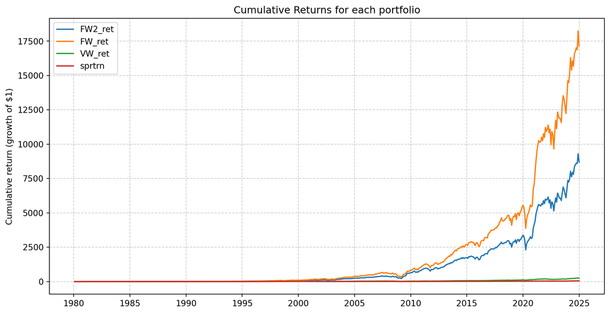

```python
Portfolios_long = (
    Portfolios.melt(id_vars='date', var_name='Strategy', value_name='Return')
              .sort_values(by=['Strategy','date'])
              .reset_index(drop=True)
)

Portfolios_long['ret_plus1'] = 1 + Portfolios_long['Return'] / 100.0
Portfolios_long['cumRet'] = Portfolios_long.groupby('Strategy')['ret_plus1'].cumprod()

# Plot cumulative returns (matplotlib)
plt.figure(figsize=(12,6))
for strat, grp in Portfolios_long.groupby('Strategy'):
    plt.plot(grp['date'], grp['cumRet'], label=strat)
plt.title('Cumulative Returns for each portfolio')
plt.ylabel('Cumulative return (growth of $1)')
plt.legend()
plt.grid(True, linestyle='--', alpha=0.6)
plt.show()
```